# compare outliers from different comparison cohorts 2023.12.01 13.25.36

hbeale

December 04, 2023

version 2023.11.27_11.25.57 adds per-patient analysis

```r
underscore_to_space <- function(x) str_replace_all(x, "_", " ")
underscore_to_space_initial_cap <- function(x) str_replace_all(x, "_", " ") %>% str_to_sentence()
```

```r
sample_metadata_file <- "../input_data/ckcc2_metadata_from_redcap_2023-11-09_10.34.27.tsv"
sample_metadata <- read_tsv(sample_metadata_file,
                            col_types = cols(.default = "c")) %>%
  mutate(dx_group_factor = fct_lump_min(dx_group, 2),
         dx_group = as.character(dx_group_factor))

n_distinct(sample_metadata$THid)
```

```
## [1] 35
```

```r
n_distinct(sample_metadata$donorID)
```

```
## [1] 33
```

```r
donor_disease <- sample_metadata %>%
  select(donorID, disease, dx_group, age_at_dx, gender) %>%
  distinct()
```

```r
outliers <- read_tsv("../input_data/druggable_outliers_from_treehouse_and_other_cohorts_2023_11_09-13_46_32_2023.tsv") %>%
  mutate(high_level_cohort = ifelse(str_detect(comparison_cohort, "Treehouse"),
                                    "Treehouse",
                                    comparison_cohort))
n_distinct(outliers$Sample_ID)
```

```
## [1] 34
```

```r
n_distinct(outliers$donor_ID)
```

```
## [1] 32
```

```r
n_distinct(outliers$gene)
```

```
## [1] 56
```

# Define cohort codes

```r
cohort_codes <- tibble(
  cohort_name =
    c("PEDAYA", "TCGA", "TH03_TH34", "Treehouse_pc", "Treehouse_pd"),
  cohort_code =
    c("P", "T", "S", "C", "D"))
```

# Tile plot of all outliers

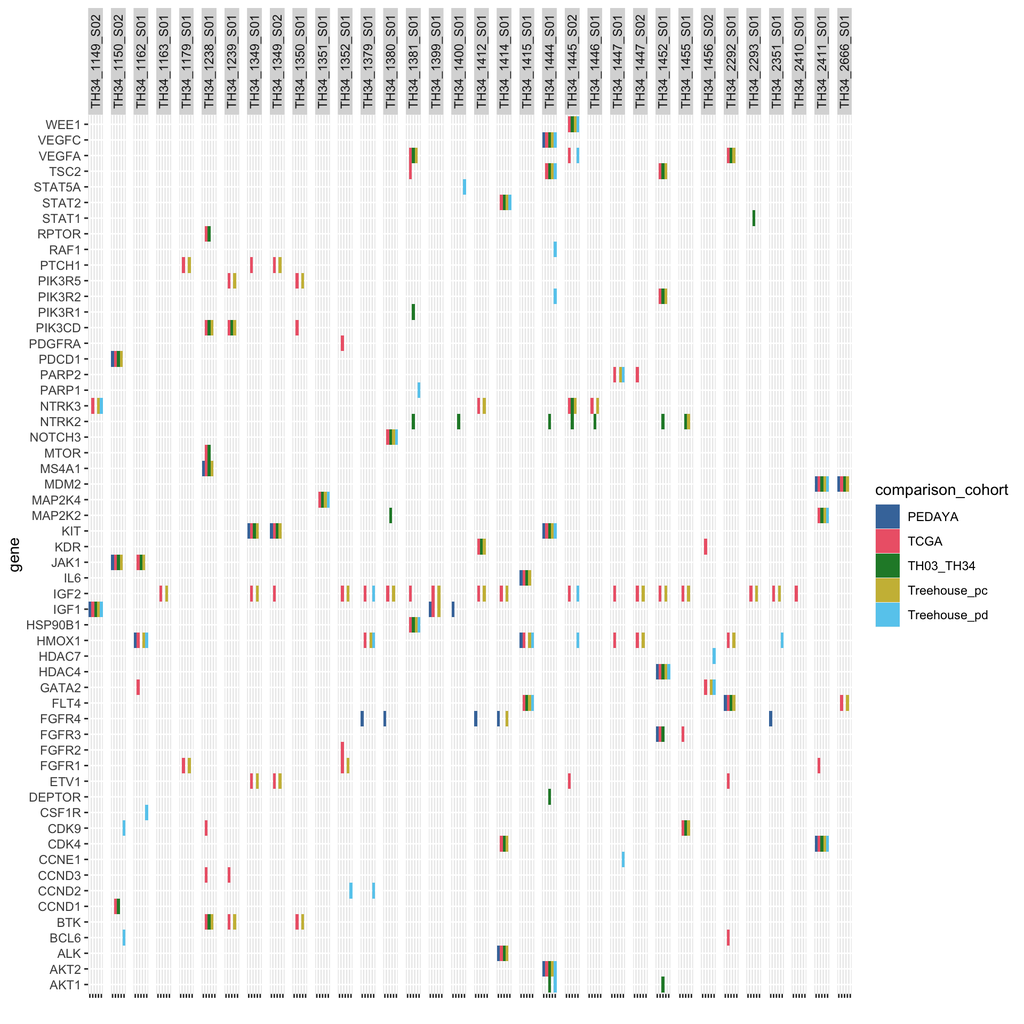

```r
ggplot(outliers) +
  geom_tile(aes(x=comparison_cohort,
                y=gene,
                fill = comparison_cohort)) +
  facet_wrap(~Sample_ID,
             nrow = 1) +
  theme(#axis.text.x = element_text(angle = 90, hjust = 1, vjust = 0.5),
    axis.text.x = element_blank(),
    strip.text.x = element_text(angle = 90),
        ) +
  xlab("")  +
  scale_fill_bright()
```

# Heatmap shows number of cohorts in which outlier were detected

I can make this look better if we decide to use it, but it’s non-trivial

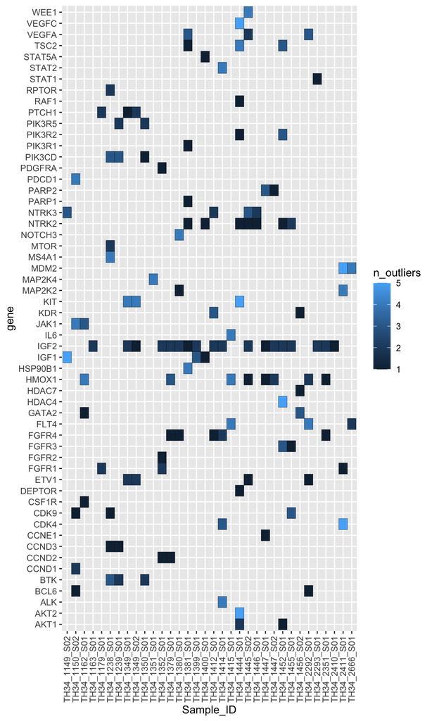

```r
outliers_heatmap_data <- outliers %>%
  group_by(Sample_ID, gene) %>%
  summarize(n_outliers = n())
ggplot(outliers_heatmap_data) +
  geom_tile(aes(x=Sample_ID,
                y=gene,
                fill = n_outliers),
            color = "black")  +
  #theme_bw() +
  theme(axis.text.x = element_text(angle = 90, hjust = 1, vjust = 0.5))
```

```r
# library(ggVennDiagram)
raw_outliers_for_venn <- outliers %>%
  mutate(sample_gene = paste(Sample_ID, gene, sep = "_")) %>%
  arrange(comparison_cohort) %>%
  select(sample_gene, comparison_cohort) %>%
  group_split(comparison_cohort)


list_of_outliers_for_venn <-  lapply(raw_outliers_for_venn, function(x) x %>% pull(sample_gene))
names(list_of_outliers_for_venn) <- unique(outliers$comparison_cohort) %>% sort

# ggVennDiagram(list_of_outliers_for_venn,
#               show_intersect = TRUE)
#
#
# ggVennDiagram(list_of_outliers_for_venn) +
#   scale_fill_distiller(palette = "Reds", direction = 1)
#
```

# export list of genes found only by TCGA

```r
outliers %>%
  group_by(Sample_ID, gene) %>%
  filter(length(comparison_cohort) == 1,
         "TCGA" %in% comparison_cohort) %>%
  ungroup %>%
  select(gene) %>% write_tsv("../gather_input_data/genes found only by TCGA in at least one sample.txt")
```

# Annotate with combined full low level cohort names

```r
collapse_fun <- function(x){ paste(x,collapse = ", ") }

all_outliers_combined_wide <- outliers %>%
  select(-pathway_support, -donor_ID, -high_level_cohort) %>%
  pivot_wider(names_from = Sample_ID,
              values_from = comparison_cohort,
              values_fn = collapse_fun)

n_distinct(outliers$Sample_ID)
```

```
## [1] 34
```

```r
n_distinct(outliers$gene)
```

```
## [1] 56
```

```r
all_outliers_combined_long <- all_outliers_combined_wide %>%
  pivot_longer(-gene,
               names_to = "Sample_ID",
               values_to = "comparison_cohorts") %>%
  na.omit()
```

# How many outliers are present in each combination of cohorts?

```r
tabyl(all_outliers_combined_long,
      comparison_cohorts) %>%
  arrange(desc(n)) %>%
  adorn_pct_formatting() %>%
  adorn_totals() %>%
  kbl() %>%
  kable_styling(full_width = F)
```

comparison_cohorts

n

percent

TCGA, Treehouse_pc

27

20.8%

TCGA

21

16.2%

Treehouse_pd

13

10.0%

TCGA, TH03_TH34, Treehouse_pc

12

9.2%

TH03_TH34

11

8.5%

PEDAYA, TCGA, TH03_TH34, Treehouse_pc

9

6.9%

TCGA, TH03_TH34, Treehouse_pc, Treehouse_pd

8

6.2%

PEDAYA, TCGA, TH03_TH34, Treehouse_pc, Treehouse_pd

7

5.4%

PEDAYA

5

3.8%

TCGA, Treehouse_pc, Treehouse_pd

4

3.1%

TCGA, TH03_TH34

3

2.3%

TCGA, Treehouse_pd

3

2.3%

PEDAYA, TCGA, Treehouse_pc, Treehouse_pd

2

1.5%

PEDAYA, TCGA, TH03_TH34

1

0.8%

PEDAYA, TCGA, Treehouse_pc

1

0.8%

PEDAYA, Treehouse_pc

1

0.8%

TH03_TH34, Treehouse_pc

1

0.8%

TH03_TH34, Treehouse_pd

1

0.8%

Total

130

# Tile plot of combination of outliers

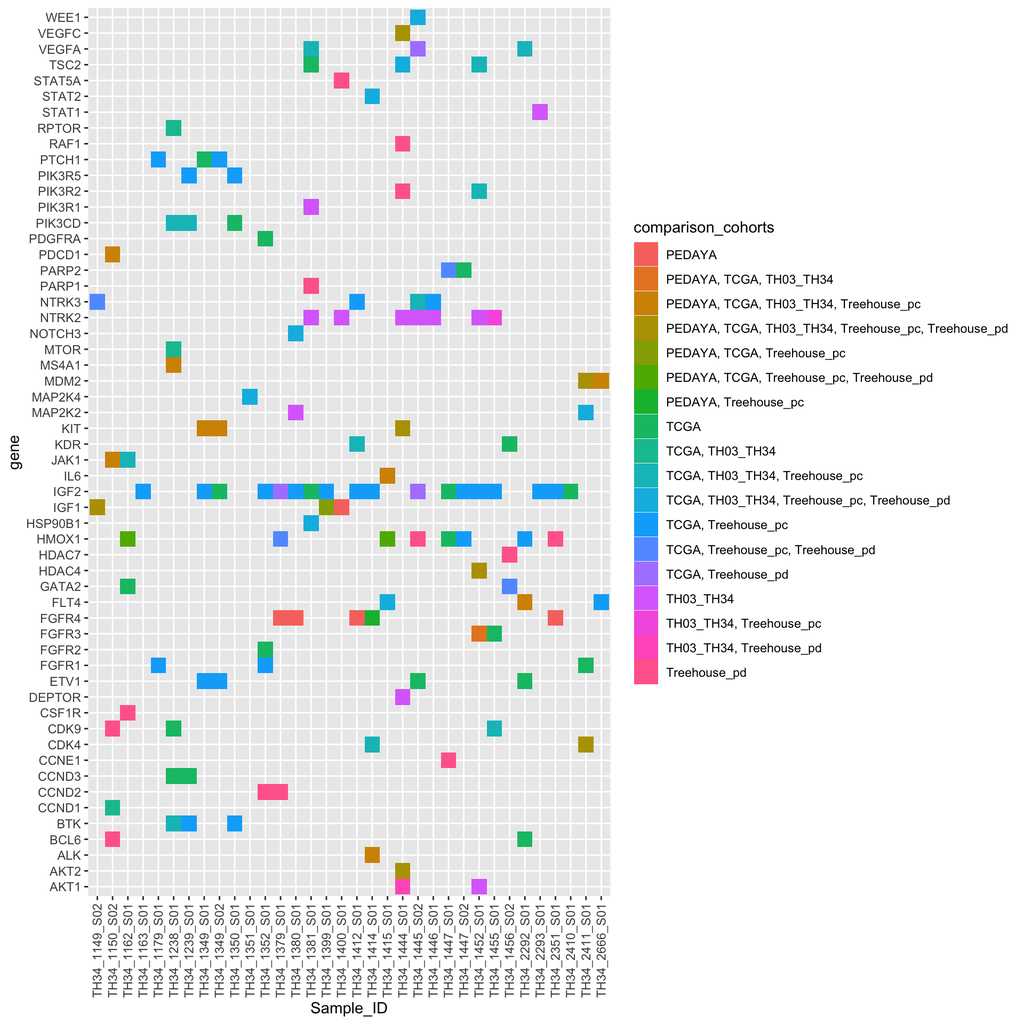

```r
ggplot(all_outliers_combined_long) +
  geom_tile(aes(x=Sample_ID,
                y=gene,
                fill = comparison_cohorts))  +
  theme(axis.text.x = element_text(angle = 90, hjust = 1, vjust = 0.5))
```

```r
n_distinct(all_outliers_combined_long$Sample_ID)
```

```
## [1] 34
```

# Annotate with combined full high level cohort names

```r
high_level_all_outliers_combined_wide <- outliers %>%
  select(-pathway_support, -donor_ID, -comparison_cohort) %>%
  distinct() %>%
  pivot_wider(names_from = Sample_ID,
              values_from = high_level_cohort,
              values_fn = collapse_fun)

n_distinct(outliers$Sample_ID)
```

```
## [1] 34
```

```r
n_distinct(outliers$gene)
```

```
## [1] 56
```

```r
high_level_all_outliers_combined_long <- high_level_all_outliers_combined_wide %>%
  pivot_longer(-gene,
               names_to = "Sample_ID",
               values_to = "comparison_cohorts") %>%
  na.omit()
```

# How many outliers are present in each high level combination of cohorts?

```r
tabyl(high_level_all_outliers_combined_long,
      comparison_cohorts) %>%
  arrange(desc(n)) %>%
  adorn_pct_formatting() %>%
  adorn_totals() %>%
  kbl() %>%
  kable_styling(full_width = F)
```

comparison_cohorts

n

percent

TCGA, Treehouse

34

26.2%

TCGA

21

16.2%

TCGA, TH03_TH34, Treehouse

20

15.4%

PEDAYA, TCGA, TH03_TH34, Treehouse

16

12.3%

Treehouse

13

10.0%

TH03_TH34

11

8.5%

PEDAYA

5

3.8%

PEDAYA, TCGA, Treehouse

3

2.3%

TCGA, TH03_TH34

3

2.3%

TH03_TH34, Treehouse

2

1.5%

PEDAYA, TCGA, TH03_TH34

1

0.8%

PEDAYA, Treehouse

1

0.8%

Total

130

# Annotate with minimal combined cohort abbreviations

```r
collapse_fun_no_coma <- function(x){ paste(x,collapse = "") }

# backslashes prevent asterisks from being interpreted as italics in the kbl table

all_outliers_min_abbrev_combined_wide <- outliers %>%
  left_join(cohort_codes,
            by=c("comparison_cohort"="cohort_name")) %>%
  mutate(cohort_code_pathway = ifelse(pathway_support,
                                      paste0(cohort_code, "\\*"),
                                      cohort_code)) %>%
  select(-pathway_support, -donor_ID,
         -comparison_cohort,
         -cohort_code) %>%
  pivot_wider(names_from = Sample_ID,
              values_from = cohort_code_pathway,
              values_fn = collapse_fun_no_coma,
              values_fill = "")


all_outliers_min_abbrev_combined_wide %>%
  arrange(gene) %>%
  rename_all(underscore_to_space) %>%
  kbl() %>%
  kable_styling(full_width = F,
                bootstrap_options = "bordered")
```

| gene | high level cohort | TH34 1162 S01 | TH34 1149 S02 | TH34 1238 S01 | TH34 1349 S01 | TH34 1349 S02 | TH34 1379 S01 | TH34 1380 S01 | TH34 1150 S02 | TH34 1399 S01 | TH34 1400 S01 | TH34 1412 S01 | TH34 1414 S01 | TH34 1415 S01 | TH34 1444 S01 | TH34 1452 S01 | TH34 2292 S01 | TH34 2351 S01 | TH34 2411 S01 | TH34 2666 S01 | TH34 1163 S01 | TH34 1179 S01 | TH34 1239 S01 | TH34 1350 S01 | TH34 1351 S01 | TH34 1352 S01 | TH34 1381 S01 | TH34 1445 S02 | TH34 1446 S01 | … |
| --- | --- | --- | --- | --- | --- | --- | --- | --- | --- | --- | --- | --- | --- | --- | --- | --- | --- | --- | --- | --- | --- | --- | --- | --- | --- | --- | --- | --- | --- | --- |
| AKT1 | TH03_TH34 |  |  |  |  |  |  |  |  |  |  |  |  |  | S* | S* |  |  |  |  |  |  |  |  |  |  |  |  |  | … |
| AKT1 | Treehouse |  |  |  |  |  |  |  |  |  |  |  |  |  | D* |  |  |  |  |  |  |  |  |  |  |  |  |  |  | … |
| AKT2 | PEDAYA |  |  |  |  |  |  |  |  |  |  |  |  |  | P* |  |  |  |  |  |  |  |  |  |  |  |  |  |  | … |
| AKT2 | TCGA |  |  |  |  |  |  |  |  |  |  |  |  |  | T* |  |  |  |  |  |  |  |  |  |  |  |  |  |  | … |
| AKT2 | TH03_TH34 |  |  |  |  |  |  |  |  |  |  |  |  |  | S* |  |  |  |  |  |  |  |  |  |  |  |  |  |  | … |
| AKT2 | Treehouse |  |  |  |  |  |  |  |  |  |  |  |  |  | C*D* |  |  |  |  |  |  |  |  |  |  |  |  |  |  | … |
| ALK | PEDAYA |  |  |  |  |  |  |  |  |  |  |  | P |  |  |  |  |  |  |  |  |  |  |  |  |  |  |  |  | … |
| ALK | TCGA |  |  |  |  |  |  |  |  |  |  |  | T |  |  |  |  |  |  |  |  |  |  |  |  |  |  |  |  | … |
| ALK | TH03_TH34 |  |  |  |  |  |  |  |  |  |  |  | S |  |  |  |  |  |  |  |  |  |  |  |  |  |  |  |  | … |
| ALK | Treehouse |  |  |  |  |  |  |  |  |  |  |  | C |  |  |  |  |  |  |  |  |  |  |  |  |  |  |  |  | … |
| BCL6 | TCGA |  |  |  |  |  |  |  |  |  |  |  |  |  |  |  | T* |  |  |  |  |  |  |  |  |  |  |  |  | … |
| BCL6 | Treehouse |  |  |  |  |  |  |  | D |  |  |  |  |  |  |  |  |  |  |  |  |  |  |  |  |  |  |  |  | … |
| BTK | TCGA |  |  | T* |  |  |  |  |  |  |  |  |  |  |  |  |  |  |  |  |  |  | T* | T* |  |  |  |  |  | … |
| BTK | TH03_TH34 |  |  | S* |  |  |  |  |  |  |  |  |  |  |  |  |  |  |  |  |  |  |  |  |  |  |  |  |  | … |
| BTK | Treehouse |  |  | C* |  |  |  |  |  |  |  |  |  |  |  |  |  |  |  |  |  |  | C* | C* |  |  |  |  |  | … |
| CCND1 | TCGA |  |  |  |  |  |  |  | T* |  |  |  |  |  |  |  |  |  |  |  |  |  |  |  |  |  |  |  |  | … |
| CCND1 | TH03_TH34 |  |  |  |  |  |  |  | S* |  |  |  |  |  |  |  |  |  |  |  |  |  |  |  |  |  |  |  |  | … |
| CCND2 | Treehouse |  |  |  |  |  | D* |  |  |  |  |  |  |  |  |  |  |  |  |  |  |  |  |  |  | D |  |  |  | … |
| CCND3 | TCGA |  |  | T* |  |  |  |  |  |  |  |  |  |  |  |  |  |  |  |  |  |  | T* |  |  |  |  |  |  | … |
| CCNE1 | Treehouse |  |  |  |  |  |  |  |  |  |  |  |  |  |  |  |  |  |  |  |  |  |  |  |  |  |  |  |  | … |
| CDK4 | PEDAYA |  |  |  |  |  |  |  |  |  |  |  |  |  |  |  |  |  | P* |  |  |  |  |  |  |  |  |  |  | … |
| CDK4 | TCGA |  |  |  |  |  |  |  |  |  |  |  | T* |  |  |  |  |  | T* |  |  |  |  |  |  |  |  |  |  | … |
| CDK4 | TH03_TH34 |  |  |  |  |  |  |  |  |  |  |  | S* |  |  |  |  |  | S* |  |  |  |  |  |  |  |  |  |  | … |
| CDK4 | Treehouse |  |  |  |  |  |  |  |  |  |  |  | C* |  |  |  |  |  | C*D* |  |  |  |  |  |  |  |  |  |  | … |
| CDK9 | TCGA |  |  | T* |  |  |  |  |  |  |  |  |  |  |  |  |  |  |  |  |  |  |  |  |  |  |  |  |  | … |
| CDK9 | TH03_TH34 |  |  |  |  |  |  |  |  |  |  |  |  |  |  |  |  |  |  |  |  |  |  |  |  |  |  |  |  | … |
| CDK9 | Treehouse |  |  |  |  |  |  |  | D |  |  |  |  |  |  |  |  |  |  |  |  |  |  |  |  |  |  |  |  | … |
| CSF1R | Treehouse | D* |  |  |  |  |  |  |  |  |  |  |  |  |  |  |  |  |  |  |  |  |  |  |  |  |  |  |  | … |
| DEPTOR | TH03_TH34 |  |  |  |  |  |  |  |  |  |  |  |  |  | S* |  |  |  |  |  |  |  |  |  |  |  |  |  |  | … |
| ETV1 | TCGA |  |  |  | T | T* |  |  |  |  |  |  |  |  |  |  | T |  |  |  |  |  |  |  |  |  |  | T |  | … |

[output cut: 111 more lines]

# Annotate with combined cohort abbreviations

```r
all_outliers_abbrev_combined_wide <- outliers %>%
  left_join(cohort_codes,
            by=c("comparison_cohort"="cohort_name")) %>%
  select(-pathway_support, -donor_ID,
         -comparison_cohort) %>%
  pivot_wider(names_from = Sample_ID,
              values_from = cohort_code,
              values_fn = collapse_fun,
              values_fill = "")
```

```r
all_outliers_abbrev_combined_wide %>%
  arrange(gene) %>%
  rename_all(underscore_to_space) %>%
  kbl() %>%
  kable_styling(full_width = F,
                bootstrap_options = "bordered")
```

| gene | high level cohort | TH34 1162 S01 | TH34 1149 S02 | TH34 1238 S01 | TH34 1349 S01 | TH34 1349 S02 | TH34 1379 S01 | TH34 1380 S01 | TH34 1150 S02 | TH34 1399 S01 | TH34 1400 S01 | TH34 1412 S01 | TH34 1414 S01 | TH34 1415 S01 | TH34 1444 S01 | TH34 1452 S01 | TH34 2292 S01 | TH34 2351 S01 | TH34 2411 S01 | TH34 2666 S01 | TH34 1163 S01 | TH34 1179 S01 | TH34 1239 S01 | TH34 1350 S01 | TH34 1351 S01 | TH34 1352 S01 | TH34 1381 S01 | TH34 1445 S02 | TH34 1446 S01 | … |
| --- | --- | --- | --- | --- | --- | --- | --- | --- | --- | --- | --- | --- | --- | --- | --- | --- | --- | --- | --- | --- | --- | --- | --- | --- | --- | --- | --- | --- | --- | --- |
| AKT1 | TH03_TH34 |  |  |  |  |  |  |  |  |  |  |  |  |  | S | S |  |  |  |  |  |  |  |  |  |  |  |  |  | … |
| AKT1 | Treehouse |  |  |  |  |  |  |  |  |  |  |  |  |  | D |  |  |  |  |  |  |  |  |  |  |  |  |  |  | … |
| AKT2 | PEDAYA |  |  |  |  |  |  |  |  |  |  |  |  |  | P |  |  |  |  |  |  |  |  |  |  |  |  |  |  | … |
| AKT2 | TCGA |  |  |  |  |  |  |  |  |  |  |  |  |  | T |  |  |  |  |  |  |  |  |  |  |  |  |  |  | … |
| AKT2 | TH03_TH34 |  |  |  |  |  |  |  |  |  |  |  |  |  | S |  |  |  |  |  |  |  |  |  |  |  |  |  |  | … |
| AKT2 | Treehouse |  |  |  |  |  |  |  |  |  |  |  |  |  | C, D |  |  |  |  |  |  |  |  |  |  |  |  |  |  | … |
| ALK | PEDAYA |  |  |  |  |  |  |  |  |  |  |  | P |  |  |  |  |  |  |  |  |  |  |  |  |  |  |  |  | … |
| ALK | TCGA |  |  |  |  |  |  |  |  |  |  |  | T |  |  |  |  |  |  |  |  |  |  |  |  |  |  |  |  | … |
| ALK | TH03_TH34 |  |  |  |  |  |  |  |  |  |  |  | S |  |  |  |  |  |  |  |  |  |  |  |  |  |  |  |  | … |
| ALK | Treehouse |  |  |  |  |  |  |  |  |  |  |  | C |  |  |  |  |  |  |  |  |  |  |  |  |  |  |  |  | … |
| BCL6 | TCGA |  |  |  |  |  |  |  |  |  |  |  |  |  |  |  | T |  |  |  |  |  |  |  |  |  |  |  |  | … |
| BCL6 | Treehouse |  |  |  |  |  |  |  | D |  |  |  |  |  |  |  |  |  |  |  |  |  |  |  |  |  |  |  |  | … |
| BTK | TCGA |  |  | T |  |  |  |  |  |  |  |  |  |  |  |  |  |  |  |  |  |  | T | T |  |  |  |  |  | … |
| BTK | TH03_TH34 |  |  | S |  |  |  |  |  |  |  |  |  |  |  |  |  |  |  |  |  |  |  |  |  |  |  |  |  | … |
| BTK | Treehouse |  |  | C |  |  |  |  |  |  |  |  |  |  |  |  |  |  |  |  |  |  | C | C |  |  |  |  |  | … |
| CCND1 | TCGA |  |  |  |  |  |  |  | T |  |  |  |  |  |  |  |  |  |  |  |  |  |  |  |  |  |  |  |  | … |
| CCND1 | TH03_TH34 |  |  |  |  |  |  |  | S |  |  |  |  |  |  |  |  |  |  |  |  |  |  |  |  |  |  |  |  | … |
| CCND2 | Treehouse |  |  |  |  |  | D |  |  |  |  |  |  |  |  |  |  |  |  |  |  |  |  |  |  | D |  |  |  | … |
| CCND3 | TCGA |  |  | T |  |  |  |  |  |  |  |  |  |  |  |  |  |  |  |  |  |  | T |  |  |  |  |  |  | … |
| CCNE1 | Treehouse |  |  |  |  |  |  |  |  |  |  |  |  |  |  |  |  |  |  |  |  |  |  |  |  |  |  |  |  | … |
| CDK4 | PEDAYA |  |  |  |  |  |  |  |  |  |  |  |  |  |  |  |  |  | P |  |  |  |  |  |  |  |  |  |  | … |
| CDK4 | TCGA |  |  |  |  |  |  |  |  |  |  |  | T |  |  |  |  |  | T |  |  |  |  |  |  |  |  |  |  | … |
| CDK4 | TH03_TH34 |  |  |  |  |  |  |  |  |  |  |  | S |  |  |  |  |  | S |  |  |  |  |  |  |  |  |  |  | … |
| CDK4 | Treehouse |  |  |  |  |  |  |  |  |  |  |  | C |  |  |  |  |  | C, D |  |  |  |  |  |  |  |  |  |  | … |
| CDK9 | TCGA |  |  | T |  |  |  |  |  |  |  |  |  |  |  |  |  |  |  |  |  |  |  |  |  |  |  |  |  | … |
| CDK9 | TH03_TH34 |  |  |  |  |  |  |  |  |  |  |  |  |  |  |  |  |  |  |  |  |  |  |  |  |  |  |  |  | … |
| CDK9 | Treehouse |  |  |  |  |  |  |  | D |  |  |  |  |  |  |  |  |  |  |  |  |  |  |  |  |  |  |  |  | … |
| CSF1R | Treehouse | D |  |  |  |  |  |  |  |  |  |  |  |  |  |  |  |  |  |  |  |  |  |  |  |  |  |  |  | … |
| DEPTOR | TH03_TH34 |  |  |  |  |  |  |  |  |  |  |  |  |  | S |  |  |  |  |  |  |  |  |  |  |  |  |  |  | … |
| ETV1 | TCGA |  |  |  | T | T |  |  |  |  |  |  |  |  |  |  | T |  |  |  |  |  |  |  |  |  |  | T |  | … |

[output cut: 111 more lines]

# Summary table for all outliers and low level cohorts

```r
n_outliers_detected_by_any_method <- outliers %>%
  select(Sample_ID, gene) %>%
  distinct %>%
  nrow()

n_outliers_with_pathway_support_detected_by_any_method <- outliers %>%
  filter(pathway_support) %>%
  select(Sample_ID, gene) %>%
  distinct %>%
  nrow()
# these have pathway support in at least one cohort

totals_tibble <-  tibble(high_level_cohort= " Total",
                         comparison_cohort = " Total",
                 n_outliers_detected = n_outliers_detected_by_any_method,
                 n_outliers_with_pathway_support = n_outliers_with_pathway_support_detected_by_any_method,
                 pct_outliers_with_pathway_support = 100*n_outliers_with_pathway_support_detected_by_any_method/n_outliers_detected_by_any_method)

outlier_summary <- outliers %>%
  group_by(comparison_cohort) %>%
  summarize(n_outliers_detected = n(),
         n_outliers_with_pathway_support = sum(pathway_support)) %>%
  ungroup() %>%
  mutate(pct_outliers_detected = 100*n_outliers_detected/n_outliers_detected_by_any_method,
         pct_outliers_with_pathway_support_detected =
           100*n_outliers_with_pathway_support/n_outliers_with_pathway_support_detected_by_any_method,
         pct_outliers_with_pathway_support = 100*n_outliers_with_pathway_support/n_outliers_detected)

outlier_summary_with_totals <-
  bind_rows(outlier_summary,
            totals_tibble %>% select(-high_level_cohort))



outlier_summary_with_totals %>%
  rename_all(underscore_to_space) %>%
  kbl(digits = c(NA, 0, 0, 0, 0)) %>%
  kable_styling(full_width = F)
```

| comparison cohort | n outliers detected | n outliers with pathway support | pct outliers detected | pct outliers with pathway support detected | pct outliers with pathway support |
| --- | --- | --- | --- | --- | --- |
| PEDAYA | 26 | 12 | 20 | 12 | NA |
| TCGA | 98 | 74 | 75 | 73 | NA |
| TH03_TH34 | 53 | 39 | 41 | 39 | NA |
| Treehouse_pc | 72 | 47 | 55 | 47 | NA |
| Treehouse_pd | 38 | 29 | 29 | 29 | NA |
| Total | 130 | 101 | NA | NA | NA |

# Summary table for all outliers and high level cohorts

```r
high_level_outlier_summary <- outliers %>%
  group_by(high_level_cohort, Sample_ID, gene) %>%
  summarize(pathway_support = any(pathway_support)) %>%
  group_by(high_level_cohort) %>%
  summarize(n_outliers_detected = n(),
         n_outliers_with_pathway_support = sum(pathway_support),
         pct_outliers_with_pathway_support = 100*n_outliers_with_pathway_support/n_outliers_detected,
         pct_outliers_detected = 100*n_outliers_detected/n_outliers_detected_by_any_method)
high_level_outlier_summary_with_totals <-
  bind_rows(high_level_outlier_summary %>%
              arrange(desc(high_level_cohort)),
            totals_tibble %>% select(-comparison_cohort))



high_level_outlier_summary_with_totals %>%
  rename_all(underscore_to_space) %>%
  kbl(format.args = list(big.mark = ","), digits = c(NA, 0, 0, 0, 0)) %>%
  kable_styling(full_width = F)
```

| high level cohort | n outliers detected | n outliers with pathway support | pct outliers with pathway support | pct outliers detected |
| --- | --- | --- | --- | --- |
| Treehouse | 89 | 64 | 72 | 68 |
| TH03_TH34 | 53 | 39 | 74 | 41 |
| TCGA | 98 | 74 | 76 | 75 |
| PEDAYA | 26 | 12 | 46 | 20 |
| Total | 130 | 101 | 78 | NA |

## Combined high and low level tables

```r
high_low <- bind_rows(
  high_level_outlier_summary_with_totals %>%
    rename(comparison_cohort=high_level_cohort) %>%
    mutate(index = c(1, 4:7)),
  outlier_summary_with_totals %>%
    filter(str_detect(comparison_cohort, "Treehouse")) %>%
    mutate(index = 2:3)
) %>%
  arrange(index) %>%
  select(-index)


high_low_outlier_summary <- high_low %>%
  filter(! str_detect(comparison_cohort, "Total")) %>%
  mutate(
    comparison_cohort = str_replace(comparison_cohort, "_", " "),
    pct_outliers_with_pathway_support_detected =
      100*n_outliers_with_pathway_support/n_outliers_with_pathway_support_detected_by_any_method,
    `Druggable outliers detected` =
      paste0(n_outliers_detected, "/", n_outliers_detected_by_any_method, " (",
             round(pct_outliers_detected), "%)"),
    `Druggable outliers with pathway support` =
      paste0(n_outliers_with_pathway_support, "/",
             n_outliers_with_pathway_support_detected_by_any_method, " (",
             round(pct_outliers_with_pathway_support_detected), "%)"),
    `Fraction of druggable outliers with pathway support` =
      paste0(n_outliers_with_pathway_support, "/",
             n_outliers_detected, " (",
             round(100*n_outliers_with_pathway_support/n_outliers_detected), "%)")
  ) %>%
  select(comparison_cohort,
         `Druggable outliers detected`,
         `Druggable outliers with pathway support`,
         `Fraction of druggable outliers with pathway support`) %>%
  bind_rows(totals_tibble %>%
              mutate(`Fraction of druggable outliers with pathway support` =
                       paste0(n_outliers_with_pathway_support, "/",
                              n_outliers_detected, " (",
                              round(100*n_outliers_with_pathway_support/n_outliers_detected), "%)"),
                     `Druggable outliers detected` = as.character(n_outliers_detected),
                     `Druggable outliers with pathway support` = as.character(n_outliers_with_pathway_support)
              ) %>%
              select(comparison_cohort,
                     `Druggable outliers detected`,
                     `Druggable outliers with pathway support`,
                     `Fraction of druggable outliers with pathway support`)
  )






high_low_outlier_summary %>%
  rename_all(underscore_to_space_initial_cap) %>%
  kbl() %>%
  kable_styling(full_width = F) %>%
  add_indent(c(2, 3), level_of_indent = 1)
```

| Comparison cohort | Druggable outliers detected | Druggable outliers with pathway support | Fraction of druggable outliers with pathway support |
| --- | --- | --- | --- |
| Treehouse | 89/130 (68%) | 64/101 (63%) | 64/89 (72%) |
| Treehouse pc | 72/130 (55%) | 47/101 (47%) | 47/72 (65%) |
| Treehouse pd | 38/130 (29%) | 29/101 (29%) | 29/38 (76%) |
| TH03 TH34 | 53/130 (41%) | 39/101 (39%) | 39/53 (74%) |
| TCGA | 98/130 (75%) | 74/101 (73%) | 74/98 (76%) |
| PEDAYA | 26/130 (20%) | 12/101 (12%) | 12/26 (46%) |
| Total | 130 | 101 | 101/130 (78%) |

# Patient level summary table for all outliers

```r
outliers %>%
  group_by(donor_ID) %>%
  summarize(any_PEDAYA = "PEDAYA" %in% comparison_cohort,
            any_TH03_TH34 = "TH03_TH34" %in% comparison_cohort,
            any_TCGA = "TCGA" %in% comparison_cohort,
            any_Treehouse_pc = "Treehouse_pc" %in% comparison_cohort,
            any_Treehouse_pd = "Treehouse_pd" %in% comparison_cohort,
            any_Treehouse = any_Treehouse_pc | any_Treehouse_pd) %>%
  pivot_longer(starts_with("any")) %>%
  mutate(name = str_remove(name, "any_")) %>%
  group_by(name) %>%
  summarize(n_patients_with_druggable_outliers = sum(value)) %>%
  kbl() %>%
  kable_styling(full_width = F)
```

| name | n_patients_with_druggable_outliers |
| --- | --- |
| PEDAYA | 18 |
| TCGA | 31 |
| TH03_TH34 | 22 |
| Treehouse | 31 |
| Treehouse_pc | 30 |
| Treehouse_pd | 18 |

# REPEAT ANALYSIS USING ONLY OUTLIERS WITH PATHWAY SUPPORT

# Tile plot of outliers with pathway support

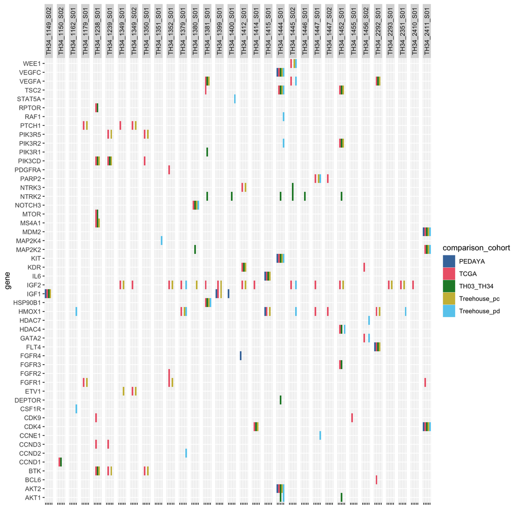

```r
ggplot(outliers %>%
         filter(pathway_support)) +
  geom_tile(aes(x=comparison_cohort,
                y=gene,
                fill = comparison_cohort)) +
  facet_wrap(~Sample_ID,
             nrow = 1) +
  theme(#axis.text.x = element_text(angle = 90, hjust = 1, vjust = 0.5),
    axis.text.x = element_blank(),
    strip.text.x = element_text(angle = 90),
        ) +
  xlab("")  +
  scale_fill_bright()
```

# Heatmap shows number of cohorts in which outlier were detected

I can make this look better if we decide to use it, but it’s non-trivial

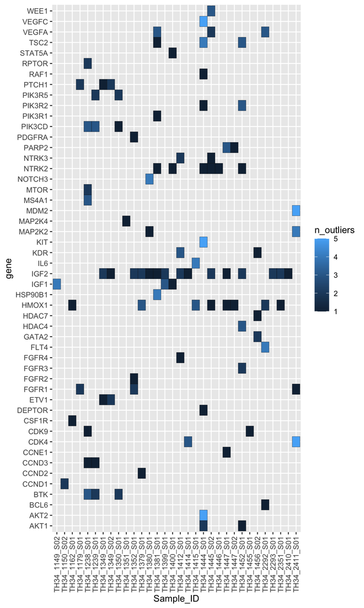

```r
pathway_outliers_heatmap_data <- outliers %>%
  filter(pathway_support) %>%
  group_by(Sample_ID, gene) %>%
  summarize(n_outliers = n())
ggplot(pathway_outliers_heatmap_data) +
  geom_tile(aes(x=Sample_ID,
                y=gene,
                fill = n_outliers),
            color = "black")  +
  #theme_bw() +
  theme(axis.text.x = element_text(angle = 90, hjust = 1, vjust = 0.5))
```

```r
raw_pathway_support_outliers_for_venn <- outliers %>%
  filter(pathway_support)  %>%
  mutate(sample_gene = paste(Sample_ID, gene, sep = "_")) %>%
  arrange(comparison_cohort) %>%
  select(sample_gene, comparison_cohort) %>%
  group_split(comparison_cohort)


list_of_pathway_support_outliers_for_venn <-  lapply(raw_pathway_support_outliers_for_venn, function(x) x %>% pull(sample_gene))
names(list_of_pathway_support_outliers_for_venn) <- outliers %>%
  filter(pathway_support) %>%
  arrange(comparison_cohort) %>%
  select(comparison_cohort) %>%
  distinct() %>%
  pull(comparison_cohort)

# ggVennDiagram(list_of_pathway_support_outliers_for_venn,
#               show_intersect = TRUE)
#
#
# ggVennDiagram(list_of_pathway_support_outliers_for_venn) +
#   scale_fill_distiller(palette = "Reds", direction = 1)
```

# Annotate with combined full cohort names

```r
outliers_with_pathway_support_combined_wide <- outliers %>%
  filter(pathway_support) %>%
  select(-pathway_support, -donor_ID) %>%
  pivot_wider(names_from = Sample_ID,
              values_from = comparison_cohort,
              values_fn = collapse_fun)

outliers_with_pathway_support_combined_long <- outliers_with_pathway_support_combined_wide %>%
  pivot_longer(c(-gene, -high_level_cohort),
               names_to = "Sample_ID",
               values_to = "comparison_cohorts") %>%
  na.omit()
```

# How many outliers with pathway support are present in each combination of cohorts?

```r
tabyl(outliers_with_pathway_support_combined_long,
      comparison_cohorts) %>%
  arrange(desc(n)) %>%
  adorn_pct_formatting() %>%
  adorn_totals() %>%
  kbl() %>%
  kable_styling(full_width = F)
```

comparison_cohorts

n

percent

TCGA

74

39.2%

TH03_TH34

39

20.6%

Treehouse_pc

35

18.5%

Treehouse_pd

17

9.0%

PEDAYA

12

6.3%

Treehouse_pc, Treehouse_pd

12

6.3%

Total

189

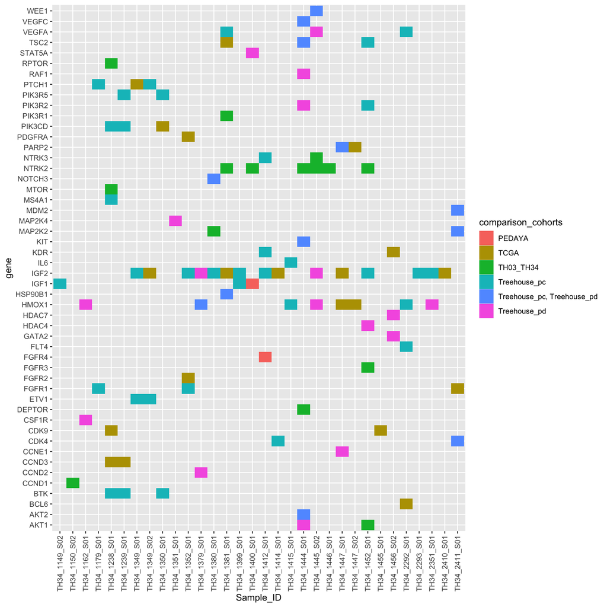

```r
ggplot(outliers_with_pathway_support_combined_long) +
  geom_tile(aes(x=Sample_ID,
                y=gene,
                fill = comparison_cohorts))  +
  theme(axis.text.x = element_text(angle = 90, hjust = 1, vjust = 0.5))
```

```r
n_distinct(outliers_with_pathway_support_combined_long$Sample_ID)
```

```
## [1] 32
```

# Patient level summary table for outliers with pathway support

```r
outliers %>%
  filter(pathway_support) %>%
  group_by(donor_ID) %>%
  summarize(any_PEDAYA = "PEDAYA" %in% comparison_cohort,
            any_TH03_TH34 = "TH03_TH34" %in% comparison_cohort,
            any_TCGA = "TCGA" %in% comparison_cohort,
            any_Treehouse_pc = "Treehouse_pc" %in% comparison_cohort,
            any_Treehouse_pd = "Treehouse_pd" %in% comparison_cohort,
            any_Treehouse = any_Treehouse_pc | any_Treehouse_pd) %>%
  pivot_longer(starts_with("any")) %>%
  mutate(name = str_remove(name, "any_")) %>%
  group_by(name) %>%
  summarize(n_patients_with_druggable_outliers = sum(value)) %>%
  kbl() %>%
  kable_styling(full_width = F)
```

| name | n_patients_with_druggable_outliers |
| --- | --- |
| PEDAYA | 8 |
| TCGA | 26 |
| TH03_TH34 | 16 |
| Treehouse | 26 |
| Treehouse_pc | 22 |
| Treehouse_pd | 13 |

# Annotate with combined cohort abbreviations

```r
outliers_with_pathway_support_abbrev_combined_wide <- outliers %>%
  filter(pathway_support) %>%
  left_join(cohort_codes,
            by=c("comparison_cohort"="cohort_name")) %>%
  select(-pathway_support, -donor_ID,
         -comparison_cohort) %>%
  pivot_wider(names_from = Sample_ID,
              values_from = cohort_code,
              values_fn = collapse_fun,
              values_fill = "")
```

# Big table of outliers with pathway support

```r
outliers_with_pathway_support_abbrev_combined_wide %>%
  arrange(gene) %>%
  rename_all(underscore_to_space) %>%
  kbl() %>%
  kable_styling(full_width = F,
                bootstrap_options = "bordered")
```

| gene | high level cohort | TH34 1149 S02 | TH34 1238 S01 | TH34 1399 S01 | TH34 1400 S01 | TH34 1412 S01 | TH34 1415 S01 | TH34 1444 S01 | TH34 1452 S01 | TH34 2292 S01 | TH34 2411 S01 | TH34 1179 S01 | TH34 1239 S01 | TH34 1349 S01 | TH34 1349 S02 | TH34 1350 S01 | TH34 1352 S01 | TH34 1379 S01 | TH34 1380 S01 | TH34 1381 S01 | TH34 1150 S02 | TH34 1414 S01 | TH34 1445 S02 | TH34 1447 S01 | TH34 1447 S02 | TH34 1455 S01 | TH34 1456 S02 | TH34 2293 S01 | TH34 2351 S01 | … |
| --- | --- | --- | --- | --- | --- | --- | --- | --- | --- | --- | --- | --- | --- | --- | --- | --- | --- | --- | --- | --- | --- | --- | --- | --- | --- | --- | --- | --- | --- | --- |
| AKT1 | TH03_TH34 |  |  |  |  |  |  | S | S |  |  |  |  |  |  |  |  |  |  |  |  |  |  |  |  |  |  |  |  | … |
| AKT1 | Treehouse |  |  |  |  |  |  | D |  |  |  |  |  |  |  |  |  |  |  |  |  |  |  |  |  |  |  |  |  | … |
| AKT2 | PEDAYA |  |  |  |  |  |  | P |  |  |  |  |  |  |  |  |  |  |  |  |  |  |  |  |  |  |  |  |  | … |
| AKT2 | TCGA |  |  |  |  |  |  | T |  |  |  |  |  |  |  |  |  |  |  |  |  |  |  |  |  |  |  |  |  | … |
| AKT2 | TH03_TH34 |  |  |  |  |  |  | S |  |  |  |  |  |  |  |  |  |  |  |  |  |  |  |  |  |  |  |  |  | … |
| AKT2 | Treehouse |  |  |  |  |  |  | C, D |  |  |  |  |  |  |  |  |  |  |  |  |  |  |  |  |  |  |  |  |  | … |
| BCL6 | TCGA |  |  |  |  |  |  |  |  | T |  |  |  |  |  |  |  |  |  |  |  |  |  |  |  |  |  |  |  | … |
| BTK | TCGA |  | T |  |  |  |  |  |  |  |  |  | T |  |  | T |  |  |  |  |  |  |  |  |  |  |  |  |  | … |
| BTK | TH03_TH34 |  | S |  |  |  |  |  |  |  |  |  |  |  |  |  |  |  |  |  |  |  |  |  |  |  |  |  |  | … |
| BTK | Treehouse |  | C |  |  |  |  |  |  |  |  |  | C |  |  | C |  |  |  |  |  |  |  |  |  |  |  |  |  | … |
| CCND1 | TCGA |  |  |  |  |  |  |  |  |  |  |  |  |  |  |  |  |  |  |  | T |  |  |  |  |  |  |  |  | … |
| CCND1 | TH03_TH34 |  |  |  |  |  |  |  |  |  |  |  |  |  |  |  |  |  |  |  | S |  |  |  |  |  |  |  |  | … |
| CCND2 | Treehouse |  |  |  |  |  |  |  |  |  |  |  |  |  |  |  |  | D |  |  |  |  |  |  |  |  |  |  |  | … |
| CCND3 | TCGA |  | T |  |  |  |  |  |  |  |  |  | T |  |  |  |  |  |  |  |  |  |  |  |  |  |  |  |  | … |
| CCNE1 | Treehouse |  |  |  |  |  |  |  |  |  |  |  |  |  |  |  |  |  |  |  |  |  |  | D |  |  |  |  |  | … |
| CDK4 | PEDAYA |  |  |  |  |  |  |  |  |  | P |  |  |  |  |  |  |  |  |  |  |  |  |  |  |  |  |  |  | … |
| CDK4 | TCGA |  |  |  |  |  |  |  |  |  | T |  |  |  |  |  |  |  |  |  |  | T |  |  |  |  |  |  |  | … |
| CDK4 | TH03_TH34 |  |  |  |  |  |  |  |  |  | S |  |  |  |  |  |  |  |  |  |  | S |  |  |  |  |  |  |  | … |
| CDK4 | Treehouse |  |  |  |  |  |  |  |  |  | C, D |  |  |  |  |  |  |  |  |  |  | C |  |  |  |  |  |  |  | … |
| CDK9 | TCGA |  | T |  |  |  |  |  |  |  |  |  |  |  |  |  |  |  |  |  |  |  |  |  |  | T |  |  |  | … |
| CSF1R | Treehouse |  |  |  |  |  |  |  |  |  |  |  |  |  |  |  |  |  |  |  |  |  |  |  |  |  |  |  |  | … |
| DEPTOR | TH03_TH34 |  |  |  |  |  |  | S |  |  |  |  |  |  |  |  |  |  |  |  |  |  |  |  |  |  |  |  |  | … |
| ETV1 | TCGA |  |  |  |  |  |  |  |  |  |  |  |  |  | T |  |  |  |  |  |  |  |  |  |  |  |  |  |  | … |
| ETV1 | Treehouse |  |  |  |  |  |  |  |  |  |  |  |  | C | C |  |  |  |  |  |  |  |  |  |  |  |  |  |  | … |
| FGFR1 | TCGA |  |  |  |  |  |  |  |  |  | T | T |  |  |  |  | T |  |  |  |  |  |  |  |  |  |  |  |  | … |
| FGFR1 | Treehouse |  |  |  |  |  |  |  |  |  |  | C |  |  |  |  | C |  |  |  |  |  |  |  |  |  |  |  |  | … |
| FGFR2 | TCGA |  |  |  |  |  |  |  |  |  |  |  |  |  |  |  | T |  |  |  |  |  |  |  |  |  |  |  |  | … |
| FGFR3 | TCGA |  |  |  |  |  |  |  | T |  |  |  |  |  |  |  |  |  |  |  |  |  |  |  |  |  |  |  |  | … |
| FGFR3 | TH03_TH34 |  |  |  |  |  |  |  | S |  |  |  |  |  |  |  |  |  |  |  |  |  |  |  |  |  |  |  |  | … |
| FGFR4 | PEDAYA |  |  |  |  | P |  |  |  |  |  |  |  |  |  |  |  |  |  |  |  |  |  |  |  |  |  |  |  | … |

[output cut: 83 more lines]

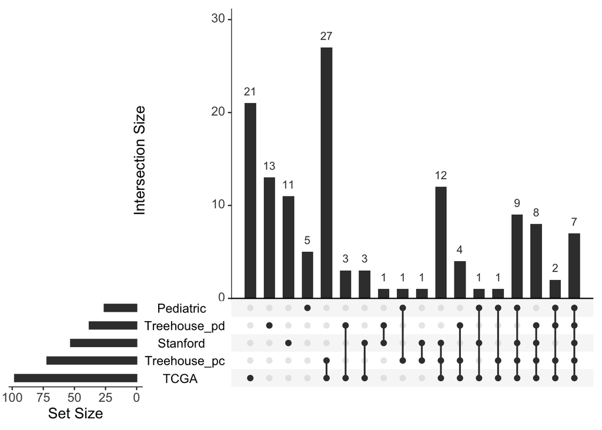

```r
outlier_upset <- outliers %>%
  mutate(index = paste(Sample_ID, gene),
         value = TRUE) %>%
  select(index, value,comparison_cohort) %>%
  pivot_wider(names_from = comparison_cohort) %>%
  select(index, TCGA, Pediatric = PEDAYA, Stanford = TH03_TH34, Treehouse_pc, Treehouse_pd) %>%
  replace_na(list(TCGA = FALSE, Pediatric = FALSE, Stanford = FALSE, Treehouse_pc = FALSE,
                  Treehouse_pd = FALSE))

outlier_upset %>%
  as.data.frame %>%
  mutate_all(as.numeric) %>%
  upset(text.scale=1.5)
```